# Groups

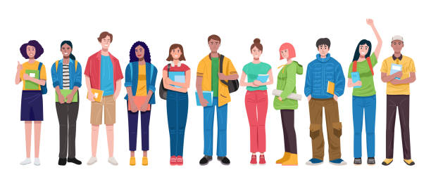

Groups define the ways students are categorized. These groups can be placed in several classifications.

# Demographic Groups

Data in this classification is collected from the student at the time of their application for admission. This data is stored at the student level, in the student table. This data is doesn’t change often, if ever. This data can be pulled as of Current, End of Term or Census.

## Gender

Gender is the biological sex on a student’s birth certificate. The options are:

- Male
- Female
- Unspecified

## IPEDS Race/Ethnicity

IPEDS Race/Ethnicity is data reporting the student’s race and ethnicity where the multiracial students are grouped into one category. There are nine options:

- Hispanic
- American Indian/Alaskan
- Asian
- Black/African American
- Hawaiian/Pacific Islander
- White
- Multiracial
- Non-Resident Alien (for those with visa’s)
- Unspecified

## Minority

Minority students are those students who are not white, non-resident alien, or unspecified. The options are:

- Minority
- Non-minority

## BIPOC

BIPOC students are those whose race/ethnicity is black, indigenous, or other people of color (Hispanic, Asian and multiracial). The options are:

- BIPOC
- non-BIPOC

## Citizenship

Citizenship is the student’s relationship to the United States. The options are:

- 1 - US Citizen
- 2 - Non-Res Alien-Visa or temp bas
- 3 - Res Alien-immigrant status
- 4 - Non-Citizen National of US
- 5 - Non-immigrant Alien 53B-8-106
- 6 - Deferred Action
- 9 - Student curr defined as Other

## International Student

An international student is a student who is from a foreign country (has a citizenship code of Non_Res Alien-Visa) and comes to the US to take classes on a temporary F-1 visa. This is a subset of Non-Resident Alien students (see IPEDS Race/Ethnicity). If the sql output is TRUE then the student is an international student.

## First Generation Student

A first generation student is a student where neither parent nor guardian has received their bachelor’s degree. On the application the student is asked if either of their parent(s) or guardian(s) has received a bachelor degree, if they respond no then the student is a first generation student. If they respond yes or if they don’t answer then the student is not a first generation student. If the sql output is TRUE then the student is a first generation student.

## Veteran

A veteran is a student who has served in the armed forces or is receiving veteran benefits (includes family members receiving benefits). If the sql output is TRUE then the student is a veteran.

## Student Athlete

A student athlete is a student who was EVER on the official team roster on or after the first scheduled contest or date of NCAA competition. If the sql output is TRUE then the student is an athlete.

## First Admit Country

First admit country is the the country listed on the students first application where they were admitted.

## First Admit State

First admit state is the the state listed on the students first application where they were admitted. Students who were not in the US get grouped into Foreign State.

## First Admit County

First admit county is the the county listed on the student first application where they were admitted. Students who were not from Utah get grouped into Out of state, in US; or Out of state, out of US.

## ACT Composite Score

ACT Composite Score is the student’s highest ACT composite score. The Composite score is the average of the four ACT test scores (Math, English, Reading, Science), rounded to the nearest whole number.

## SQL for Demographic Groups

```sql
--This query will pull current data from the current term (use student_version to pull snapshot data and version_desc equals 'Census' or 'End of Term')
SELECT a.student_id,
       a.gender_code,
       CASE
           WHEN a.gender_code = 'M' THEN 'Male'
           WHEN a.gender_code = 'F' THEN 'Female'
           ELSE 'Unspecified'
           END AS gender_desc,
       a.ipeds_race_ethnicity,
       CASE
          WHEN a.ipeds_race_ethnicity = 'White' THEN 'Non-Minority'
          WHEN a.ipeds_race_ethnicity = 'Unspecified' THEN 'Non-Minoirity'
          WHEN a.ipeds_race_ethnicity = 'Non-resident Alien' THEN 'Non-Minority'
          ELSE 'Minority'
       END AS minority,
       CASE
           WHEN a.is_american_indian_alaskan = 'TRUE' THEN 'BIPOC'
           WHEN a.is_asian = 'TRUE' THEN 'BIPOC'
           WHEN a.is_black = 'TRUE' THEN 'BIPOC'
           WHEN a.is_hawaiian_pacific_islander = 'TRUE' THEN 'BIPOC'
           WHEN a.is_hispanic_latino_ethnicity = 'TRUE' THEN 'BIPOC'
           WHEN a.is_multi_racial = 'TRUE' THEN 'BIPOC'
           ELSE 'non-BIPOC'
           END AS BIPOC_student,
       a.us_citizenship_code,
       a.us_citizenship_desc,
       a.is_international,
       CASE
              WHEN EXTRACT(YEAR from AGE(current_date, a.birth_date)) < 18 THEN 'less than 18'
              WHEN EXTRACT(YEAR from AGE(current_date, a.birth_date)) BETWEEN 18 and 24 THEN '18 to 24'
              WHEN EXTRACT(YEAR from AGE(current_date, a.birth_date)) BETWEEN 25 and 34 THEN '25 to 34'
              WHEN EXTRACT(YEAR from AGE(current_date, a.birth_date)) BETWEEN 35 and 44 THEN '35 to 44'
              WHEN EXTRACT(YEAR from AGE(current_date, a.birth_date)) BETWEEN 45 and 59 THEN '45 to 59'
              WHEN EXTRACT(YEAR from AGE(current_date, a.birth_date)) > 59 THEN '60 plus'
              ELSE 'error'
          END AS age_band,
       a.is_first_generation,
       a.is_athlete,
       a.is_veteran,
       a.first_admit_country_desc,
       a.first_admit_state_desc,
       a.first_admit_county_desc,
       a.act_composite_score
  FROM export.student a --comment out this row and uncomment out the two rows below if you want snapshot data
  --FROM export.student_version a
  --WHERE a.version_desc = 'Census'
```

# Term Based Groups

Data in this classification can change each semester and is based on information from the system for this current term such as program, student type, etc. This data is stored at the student term level, in the student_term_level table. This data changes often. This data can be pulled as of Current, End of Term or Census.

## College

College id/desc indicates what college a student belongs to based on the primary program the student has declared. Programs are assigned to a department and departments are assigned to colleges (abbreviation/desc). There are eight options:

- COB - College of Business
- COE - College of Education
- COA - College of the Arts
- GCO - College of Global and Community Outreach
- COHS - College of Health Sciences
- CHASS - College of Humanities and Social Sciences
- CSET - College of Science, Engineering and Technology
- UCOL - University College

## Department

Department id/desc indicates what department a student belongs to based on the primary program the student has declared. Programs are assigned to a department and departments are assigned to colleges.

## Program

Program id/desc is the students’ declared program of study. Programs are assigned to a department and departments are assigned to colleges. A program code is made up of a degree id, and major id and if applicable a concentration id.

## Concentration

Concentration id/desc is a specific area of emphasis or specialization in a major chosen by a student. Not all majors have a concentration option.

## Degree

Degree id/desc is the degree that is tied to a students’ primary program of study.

## Major

Major id/desc is the major that is tied to a students’ primary program of study.

## Degree Seeking Student

A student is a degree seeking student if the students’ primary program leads to a credential. This includes Associate, Bachelor, and Master’s students. If the sql output is TRUE then the student is a degree seeking student.

## Student Type

Student Type is a student’s enrollment status or registration status for the term. The options are:

- H - High School - A student who is taking classes from the institution while still in high school. This code will be given to the student every term they enroll while still in high school.
- F - Freshman - A student who is attending any institution for the first time at the undergraduate level in a degree seeking program after graduation from high school. Includes students enrolled in the fall term who attended college for the first time in the prior summer term, and students who entered with advanced standing (college credits earned before graduation from high school (e.g., advanced placement and concurrent enrollment)). A student will be coded as a freshman only once.
- C - Continuing Registration - A student who is re-enrolling at the institution after having attended the previous term. Includes a student who attends spring term, stops out summer term, then returns fall term.
- R - Readmit - A student who has re-enrolled at the institution after stopping out for at least one term (excluding summer term).
- T - Transfer - A student entering the reporting institution for the first time but known to have previously attended a post secondary institution at the same level (e.g., undergraduate, graduate). This includes new students enrolled in the fall term who transferred into the institution the prior summer term. The student may transfer with or without credit. A student will be coded as a transfer only once.
- P - Personal Interest, Non-Degree - A student who is taking courses without applying for candidacy for a degree or certificate.
- 1 - New Graduate - A student who holds a bachelors or first professional degree, or equivalent, and is taking courses at the post baccalaureate level for the first time. These students may or may not be enrolled in graduate programs. A student will be coded as a new graduate only once.
- 2 - Transfer Graduate - A student entering the reporting institution at the graduate level for the first time but known to have previously attended another post secondary institution at the graduate level. The student may transfer in with or without credit. A student will be coded as a transfer graduate only once.
- 3 - Readmit Graduate - A student who has re-enrolled at the institution after stopping out for at least one term of graduate coursework (excluding summer term).
- 5 - Continuing Graduate - A graduate student who is re-enrolling at the institution after having attended a previous term as a graduate student.

## Student Level

Student level is the level of the primary degree a student is pursing. The options are: Undergraduate or Graduate.

## Class Level

Class level is based on a student’s overall cumulative earned credit hours. A student’s class level is not the same as their year in school, it is based on credit hours. There can be sophomores in their first semester, as well as freshmen in their third year.

All graduate students are reported as Graduate. Undergraduate students have four options, the options are:

- Freshman <30 credit hours
- Sophomore 30-59 credit hours
- Junior 60-89 credit hours
- Senior 90 or more credit hours

## Course Load

Course load is the status of a student’s time commitment based on how many credit hours attempted and the student’s level for a given semester. The options are:

- Full-time for Undergraduate students, 12 or more credit hours; for Graduate students 9 or more credit hours
- Part-time for Undergraduate students, less than 12 credit hours; for Graduate students less than 9 credit hours.

## Tuition Residency

Tuition Residency is the official status of student’s residence for tuition purposes. The options are:

- 0 - Undeclared
- A - American Indian Tribal Resident
- B - Housebill 102 - 2023
- C - Changed from Non-Resident
- G - Good Neighbor Tuition
- H - Housebill 118/144 Waivers
- M - Military, Out-of-State
- N - Non-Resident of UT
- R - UT Resident
- S - Surcharge for excessive credits

## State Residency

State Residency summarizes tuition residency into two categories, in-state or out-of-state. The options are:

- In-state residency
- Out-of-state residency

## High School Student

A High School Student is a student is who is taking a course at Utah Tech University while still attending high school. High school is a subset of Non-degree-seeking. If the sql output is TRUE then the student is a high school student.

## Non-Matriculated

A non-matriculated student is a non-degree-seeking student who is enrolled to per sue personal interests, not a credential. Non-matriculated is a subset of Non-degree-seeking. If the sql output is TRUE then the student is a non-matriculated student.

## Online Program Student

An Online Program Student is a student who is paying online tuition because they are in an online only program (the program can only be completed online). If the sql output is TRUE then the student is an online program student.

## Overall Cumulative GPA Band

Overall Cumulative GPA Band displays a student’s Overall (both institutional and transfer) Cumulative (across all semesters) GPA. Best used at End of Term. Reported as a grouping:

- new (null - no GPA yet)
- 0-1.999
- 2-2.49
- 2.5-2.999
- 3-4.0

## Institutional Term GPA Band

Institutional Term GPA Band displays a student’s Institutional Term GPA. Best used at End of Term. Reported as a grouping:

## Pell Eligible

A Pell Eligible student is a student who is eligible to receive a Pell grant this term based on their FAFSA. If the sql output is TRUE then the student is Pell eligible.

## Pell Awarded

A Pell Awarded student is a student who has been awarded a Pell grant this term. If the sql output is TRUE then the student is Pell Awarded.

## Subsidized Loan Awarded

A Subsidized Loan Awarded student is a student who has been awarded a Subsidized Loan this term. If the sql output is TRUE then the student is Subsidized Loan Awarded.

## Student Athlete Term

A Student Athlete is a student who was on the official team roster on or after the first scheduled contest or date of NCAA competition that semester. If the sql output is TRUE then the student is an athlete.

## SQL for Term Based Groups

```sql
--This query will pull current data from the current term (use student_term_level_version to pull snapshot data and version_desc equals 'Census' or 'End of Term')
SELECT a.student_id,
       b.college_abbrv,
       b.college_desc,
       b.department_id,
       b.department_desc,
       a.primary_program_id AS program_id,
       a.primary_program_desc AS program_desc,
       a.primary_concentration_id AS concentration_id,
       a.primary_concentration_desc AS concentration_desc,
       a.primary_degree_id AS degree_id,
       a.primary_degree_desc AS degree_desc,
       b.major_id,
       b.major_desc,
       a.is_degree_seeking,
       a.student_type_code,
       a.student_type_desc,
       CASE
           WHEN a.student_type_code = 'H' THEN TRUE
           ELSE FALSE
        END AS is_high_school,
       a.level_id AS student_level_id,
       a.level_desc AS student_level_desc,
       a.primary_level_class_id AS class_level_id,
       a.primary_level_class_desc AS class_level_desc,
       a.full_time_part_time_code AS course_load,
       a.residency_code AS tuition_residency_code,
       a.residency_code_desc AS tuition_residency_desc,
       a.residency_in_state_code AS state_residency_code,
       a.residency_in_state_desc AS state_residency_desc,
       CASE
           WHEN a.student_type_code = 'H' THEN TRUE
           ELSE FALSE
        END AS is_high_school,
       CASE
           WHEN a.student_type_code = 'P' THEN TRUE
           ELSE FALSE
        END AS is_non_matriculated,
       a.is_online_program_student,
       CASE
           WHEN a.overall_cumulative_gpa < 2.0 THEN '0_to_1.999'
           WHEN a.overall_cumulative_gpa BETWEEN 2.0 AND 2.499 THEN '2_to_2.499'
           WHEN a.overall_cumulative_gpa BETWEEN 2.5 AND 2.999 THEN '2.5_to_2.999'
           WHEN a.overall_cumulative_gpa BETWEEN 3.0 AND 4 THEN '3_to_4'
           ELSE 'new'
       END AS overall_cumulative_gpa_band,
        CASE
           WHEN a.institutional_term_gpa < 2.0 THEN '0_to_1.999'
           WHEN a.institutional_term_gpa BETWEEN 2.0 AND 2.499 THEN '2_to_2.499'
           WHEN a.institutional_term_gpa BETWEEN 2.5 AND 2.999 THEN '2.5_to_2.999'
           WHEN a.institutional_term_gpa BETWEEN 3.0 AND 4 THEN '3_to_4'
           ELSE 'new'
        END AS institutional_term_gpa,
       a.is_pell_eligible,
       a.is_pell_awarded,
       a.is_pell_awarded,
       a.is_subsidized_loan_awarded,
       a.is_athlete AS student_athlete_term
  FROM export.student_term_level a --comment out this line and then uncomment the line below and the version_desc line if you want snapshot data
  --FROM export.student_term_level_version a
  LEFT JOIN export.academic_programs b ON b.program_id = a.primary_program_id
 WHERE a.is_enrolled IS TRUE
   AND a.is_primary_level IS TRUE
   AND a.is_current_term IS TRUE
   --AND a.version_desc = 'Census';
```

# Course Based Groups

## High School Concurrent Enrollment Student

A High School Concurrent Enrollment student is a high school student enrolled in at least one funded concurrent enrollment class. High School Concurrent Enrollment students are a subset of High School Students. If a high school student isn’t a concurrent enrollment student then the student is a High School Student, Other. If the sql output is TRUE then the student is a high school concurrent enrollment student.

## SQL for High School Concurrent Enrollment Student

```sql
--This query will pull current data from the current term (use student_term_level_version to pull snapshot data)
WITH cte AS
           (
               SELECT a.budget_code,
                      b.student_type_code,
                      a.student_id,
                      a.course_id,
                      a.term_id
                 FROM export.student_section a
                          LEFT JOIN export.student_term_level b
                                    ON b.student_id = a.student_id
                                        AND b.term_id = a.term_id
                                        AND b.is_primary_level IS TRUE
                WHERE a.is_enrolled IS TRUE
                  AND a.is_current_term IS TRUE
                ORDER BY a.student_id
           ),
       concurrent_cte AS ( --this query flags student courses that are eligible for concurrent enrollment funds
           SELECT a.student_id,
                  a.term_id,
                  CASE
                      WHEN a.student_type_code = 'H' AND (a.budget_code IN ('BC', 'SF'))
                          THEN TRUE
                      ELSE FALSE
                      END AS cte_concurrent_enrollment
             FROM cte a
       )
SELECT a.student_id,
       a.term_id,
       bool_or(cte_concurrent_enrollment) AS is_concurrent_enrollment
  FROM concurrent_cte a
 GROUP BY a.student_id, a.term_id
```

## Distance Education Status

Distance Education Status determines if a students’ courses are Distance Education All, Distance Education Some, or Distance Education None. A distance education course uses one or more types of technology to deliver instruction to students who are separated from the instructor and to support regular and substantive interaction between the students and the instructor synchronously or asynchronously.

## SQL for Distance Education Status

```sql
--This query will pull current data from the current term (use student_term_level_version to pull snapshot data)
SELECT a.student_id,
       a.is_distance_ed_all,
       a.is_distance_ed_some,
       a.is_distance_ed_none
  FROM export.student_term_level a
 WHERE a.is_enrolled IS TRUE
   AND a.is_primary_level IS TRUE
   AND a.is_current_term IS TRUE
```

## Online Status

Online Status determines if a students courses are Online All, Online Some, or Online None. An online course is a subset of distance education courses. Online courses are primarily delivered asynchronously; students work at their own pace within the timelines established by the instructor.

## SQL for Online Status

```sql
--This query will pull current data from the current term (use student_section_version to pull snapshot data)
SELECT student_id,
       instruction_method_code_aggregated,
       instruction_method_code_aggregated !~ '[I]'  AS online_none,
       instruction_method_code_aggregated !~ '[^I]' AS online_all,
       CASE
           WHEN instruction_method_code_aggregated !~ '[^I]' THEN FALSE
           WHEN instruction_method_code_aggregated ~ '[I]+' THEN TRUE
           ELSE FALSE
           END                                      AS online_some,
       academic_year_code
FROM (SELECT a.student_id,
             STRING_AGG(instruction_method_code :: VARCHAR, ''
                        ORDER BY instruction_method_code) AS instruction_method_code_aggregated,
             b.academic_year_code
      FROM export.student_section a
               LEFT JOIN export.term b ON b.term_id = a.term_id
      WHERE is_enrolled
        AND season != 'Summer'
      GROUP BY a.student_id,
               b.academic_year_code) x
```

## Student Category

A student’s category is based off of their degree seeking status. The options are:

- Degree Seeking
- Non-Matriculated
- High School Concurrent Enrollment Students
- High School Students, Other

## SQL for Student Category

```sql
--This query will pull current data from the current term (use student_term_level_version and student_section_version to pull snapshot data)
WITH cte_degree_seeking AS
         (SELECT a.student_id,
                 a.term_id,
                 a.is_degree_seeking
          FROM export.student_term_level a
          WHERE a.is_enrolled IS TRUE
            AND a.is_primary_level IS TRUE
            AND a.is_current_term IS TRUE
          ORDER BY a.student_id),
     cte_non_matriculated AS
         (SELECT a.student_id,
                 a.term_id,
                 CASE
                     WHEN a.student_type_code = 'P' THEN 'TRUE'
                     ELSE 'FALSE'
                     END AS is_non_matriculated
          FROM export.student_term_level a
          WHERE a.is_enrolled IS TRUE
            AND a.is_primary_level IS TRUE
            AND a.is_current_term IS TRUE
          ORDER BY a.student_id),
     cte_high_school AS
         (SELECT a.student_id,
                 a.term_id,
                 CASE
                     WHEN a.student_type_code = 'H' THEN 'TRUE'
                     ELSE 'FALSE'
                     END AS is_high_school
          FROM export.student_term_level a
          WHERE a.is_enrolled IS TRUE
            AND a.is_primary_level IS TRUE
            AND a.is_current_term IS TRUE
          ORDER BY a.student_id),
     cte_concurrent AS
         (WITH cte AS
                   (SELECT a.budget_code,
                           b.student_type_code,
                           a.student_id,
                           a.course_id,
                           a.term_id
                    FROM export.student_section a
                             LEFT JOIN export.student_term_level b
                                       ON b.student_id = a.student_id
                                           AND b.term_id = a.term_id
                                           AND b.is_primary_level IS TRUE
                    WHERE a.is_enrolled IS TRUE
                      AND a.is_current_term IS TRUE
                    ORDER BY a.student_id),
               concurrent_cte AS ( --this query flags student courses that are eligible for concurrent enrollment funds
                   SELECT a.student_id,
                          a.term_id,
                          CASE
                              WHEN a.student_type_code = 'H' AND (a.budget_code IN ('BC', 'SF'))
                                  THEN TRUE
                              ELSE FALSE
                              END AS cte_concurrent_enrollment
                   FROM cte a)
          SELECT a.student_id,
                 a.term_id,
                 bool_or(cte_concurrent_enrollment) AS is_concurrent_enrollment
          FROM concurrent_cte a
          GROUP BY a.student_id, a.term_id)
SELECT a.student_id,
       a.term_id,
       b.is_degree_seeking,
       c.is_non_matriculated,
       d.is_high_school,
       e.is_concurrent_enrollment,
       CASE WHEN b.is_degree_seeking = 'TRUE' THEN 'degree-seeking'
            WHEN c.is_non_matriculated = 'TRUE' THEN 'non-matriculated'
            WHEN d.is_high_school = 'TRUE' AND e.is_concurrent_enrollment = 'TRUE' THEN 'high_school_concurrent'
            WHEN d.is_high_school = 'TRUE' AND e.is_concurrent_enrollment = 'FALSE' THEN 'high_school_other'
            ELSE 'error'
            END AS student_categories
FROM export.student_term_level a
         LEFT JOIN cte_degree_seeking b
                   ON b.student_id = a.student_id AND b.term_id = a.term_id
         LEFT JOIN cte_non_matriculated c
                   ON c.student_id = a.student_id AND c.term_id = a.term_id
         LEFT JOIN cte_high_school d
                   ON d.student_id = a.student_id AND d.term_id = a.term_id
         LEFT JOIN cte_concurrent e
                   ON e.student_id = a.student_id AND e.term_id = a.term_id
WHERE a.is_enrolled IS TRUE
  AND a.is_primary_level IS TRUE
  AND a.is_current_term IS TRUE
```